# Week 3 Homework Doing Data Science

Brian Waite

November 22, 2018

# 1. GitHub Cloning (20 points):

```r
# cd Documents\GitHub\Testrepo
# mkdir publicdata
# cd publicdata
# git clone https://github.com/caesar0301/awesome-public-datasets
# cd awesome-public-datasets\Datasets
```

# 2. Data Summary (20 points):

### 2.a: Read in titanic.csv

```r
# unzip titanic.csv.zip
setwd("C:/Users/Brian/Documents/Github/Testrepo/publicdata/awesome-public-datasets/Datasets")
df = read.csv("titanic.csv")
```

### 2.b: Output count of females and males aboard the Titanic. Plot the frequency of females and males.

```r
sexDF = summary(df$Sex)
print(sexDF)
```

```
## female   male
##    314    577
```

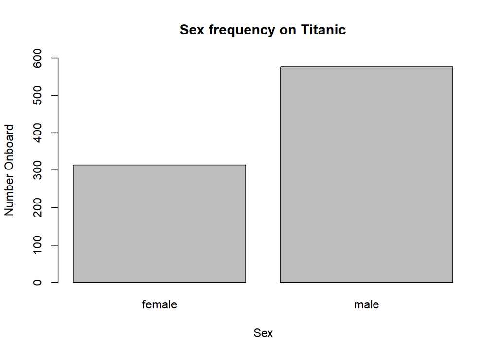

```r
barplot(sexDF, ylim = c(0,600), xlab = "Sex", ylab = "Number Onboard", main = "Sex frequency on Titanic")
```

### 2.c: Use one apply function to output the means of Age, Fare, and Survival.

```r
lapply(df[,c(2,6,10)], mean, na.rm=TRUE)
```

```
## $Survived
## [1] 0.3838384
##
## $Age
## [1] 29.69912
##
## $Fare
## [1] 32.20421
```

# 3. Function Building (30 points)

### Prep step: Load the data in sleep01.csv

```r
sleepdata = read.csv("http://talklab.psy.gla.ac.uk/L1_labs/lab_1/homework/sleep_data_01.csv")
```

### Build the function for building the report.

```r
###This function accepts a dataframe in the format of sleep_data_01.csv imported into a dataframe
###It returns a report of the sleep data consisting of the median age, RSES mean, RSES std. deviation
###(all divided by 5) and the range of Duration.

sleepFunction = function(x) {
  medianAge = median(x$Age, na.rm = TRUE)
  minDuration = min(x$Duration,na.rm = TRUE)
  maxDuration = max(x$Duration, na.rm = TRUE)
  meanRSES = mean(x$RSES, na.rm = TRUE)
  sdRSES = sd(x$RSES, na.rm = TRUE)
  report = as.data.frame(t(c(medianAge/5,meanRSES/5,sdRSES/5,maxDuration - minDuration)))
  names(report) = c("MedianAge", "SelfEsteem", "SE_SD", "DurationRange")
  round(report, 2) #returns report rounded to 2 decimal places at most
  }
```

### Run the function using the sleep data provided.

```r
sleepFunction(sleepdata)
```

```
##   MedianAge SelfEsteem SE_SD DurationRange
## 1       2.8       3.62  1.24             7
```

# 4. FiveThirtyEight Data (30 points):

### a. Install the fivethirtyeight package

```r
#commenting the install code to avoid issues in compiling the knit file

#install.packages("fivethirtyeight")

#load
library(fivethirtyeight)
```

### Find the data set name of the 22nd data set

```r
#get a list of all sets
setListing = data(package = "fivethirtyeight")
#find the 22nd set variable name
as.name(setListing$results[22,3])
```

```
## college_recent_grads
```

### b. Assign the data identified to a new dataframe df

```r
#assign the dataframe to the identified value. Couldn't get this to take programmatically with as.name, call, eval, etc... Not sure why.
df = fivethirtyeight::college_recent_grads
```

### c. Use a more detailed list of the datasets to print out a URL in a comment to the news story.

```r
#find the record
largeSetListing = read.csv("https://goo.gl/OT8iHa")
articleURL = as.character(largeSetListing[which(largeSetListing$DATAFRAME_NAME == setListing$results[22,3]),12])
```

I am really happy to hear from this news story that non-STEM majors can also find ways to make money!

```r
print(articleURL)
```

```
## [1] "http://fivethirtyeight.com/features/the-economic-guide-to-picking-a-college-major/"
```

### d. Using R commands, give the dimension and column names of the dataframe

Dimensions of dataframe df:

```r
dim(df)
```

```
## [1] 173  21
```

Column names of dataframe df:

```r
names(df)
```

```
##  [1] "rank"                        "major_code"
##  [3] "major"                       "major_category"
##  [5] "total"                       "sample_size"
##  [7] "men"                         "women"
##  [9] "sharewomen"                  "employed"
## [11] "employed_fulltime"           "employed_parttime"
## [13] "employed_fulltime_yearround" "unemployed"
## [15] "unemployment_rate"           "p25th"
## [17] "median"                      "p75th"
## [19] "college_jobs"                "non_college_jobs"
## [21] "low_wage_jobs"
```

# 5 Data Summary (30 points):

### a. Write an R command to get the column names and count the number of columns.

Again, the column names are:

```r
names(df)
```

```
##  [1] "rank"                        "major_code"
##  [3] "major"                       "major_category"
##  [5] "total"                       "sample_size"
##  [7] "men"                         "women"
##  [9] "sharewomen"                  "employed"
## [11] "employed_fulltime"           "employed_parttime"
## [13] "employed_fulltime_yearround" "unemployed"
## [15] "unemployment_rate"           "p25th"
## [17] "median"                      "p75th"
## [19] "college_jobs"                "non_college_jobs"
## [21] "low_wage_jobs"
```

And the number of columns is the length of that object:

```r
length(names(df))
```

```
## [1] 21
```

### b. Generate a count of each unique major_category in data frame with frequency of each.

```r
major_count = as.data.frame(table(df$major_category))
names(major_count) = c("Major", "Frequency")
```

### c. Make a barplot of major_count

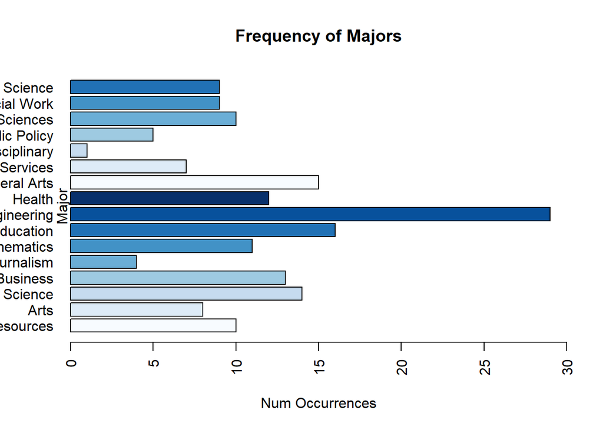

```r
par(las=2)
barplot(major_count$Frequency, names.arg = major_count$Major, col = blues9, horiz = TRUE, xlim = c(0,30), xlab = "Num Occurrences", main = "Frequency of Majors")

title(ylab="Major", line=0, cex.lab=1.0)
```

### d. Write the fivethirtyeight data to a csv file. Make sure that it does not have row labels.

```r
write.csv(df, "college_recent_grads.csv", row.names = FALSE)
```

# 6. Codebook (30 points)

### a. Start a new repository on GitHub for your SMU MSDS homework. (Complete)

### b. Create a README.md file which explains the purpose of the repository. (Complete)

### c. In one (or more) of the nested directories, post your RMarkdown script, HTML file, and data from ‘fivethirtyeight.’ (complete)

### d. The link to this repository meeting the above requirements is available at:

https://github.com/Ujustwaite/Testrepo/tree/master/homework

## Homework 3 Complete!